# 第9回 顔画像を、少ない数で持つ

## 前回からの接続

前回は、2,000本の遺伝子を一緒に動くまとまりに分け、まとまりごとの平均で、たくさんの列を10本ほどの点数に縮めました。平均は、いちばん単純な縮め方でした。

今日は、たくさんの数でできたデータを、できるだけ情報を失わずに少ない数に縮める方法を学びます。題材は、顔の画像です。顔の画像1枚は、4,096個の数でできています。

## 今日の分析目標

あなたは、顔認証を作る開発チームの一員です。顔の画像1枚（4,096画素）を、誰の顔かを見分ける力を保ったまま、何個の数で持てばよいかに答える。

40人の顔の画像400枚を使います。データを、平均からのずれの誤差がいちばん小さくなる向きで近似する方法（主成分分析）を、2画素の小さな例から組み立て、4,096画素の顔に広げます。

もう1つのねらいは、表を行列として見て、縮める・戻すを行列の積で書けるようになることです。最後の「目標に答えられたか」で振り返りましょう。

### 場面

あなたは、建物の入館ゲートの顔認証を作る開発チームの一員です。前もって登録した人の顔の画像と、カメラに写った顔を比べて、誰の顔かを当てます。

顔の画像1枚は、4,096個の数です。登録した人が増えると、そのまま持つと記憶も重く、比べる計算も重くなります。1枚を、もっと少ない数で持てないでしょうか。ただし、少なくしすぎて、誰の顔かを見分けられなくなっては困ります。

### 手元のデータ

英国ケンブリッジのAT&T研究所が1992〜1994年に撮った顔の画像です（Olivettiの顔画像。scikit-learnが配布しています）。40人について、1人10枚ずつ、表情や眼鏡の有無、顔の向きを少しずつ変えて撮ってあります。

1枚は、縦64 × 横64＝4,096画素の白黒の画像です。値は画素の明るさで、0が黒、1が白です。1行が1枚で、先頭の列`person`が人の番号（0〜39）、残りの4,096列が画素の明るさです。

### 最後に出す答え

顔の画像1枚を何個の数で持てばよいかと、その数で持ったときに、誰の顔かを当てる力がどれだけ残るか（正解率）です。

## 学習ゴール

この回を終えると、次のことができるようになります。

- 画像を数の並び（行）として表し、`reshape`で画像に戻せる
- 平均からのずれを、1本の向きで近似し、誤差がいちばん小さい向きを探せる。それが散らばりのいちばん大きい向きでもあることを説明できる
- 主成分分析で向き（主成分）と得点を求め、向きを顔として描いて読める
- 得点＝ずれ`@`向きの転置、再構成＝得点`@`向き＋平均、を行列の積で書ける
- 累積寄与率と再構成誤差で、何本の主成分でどれだけ残るかを確かめられる
- 1-最近傍法で顔を見分け、主成分分析をパイプライン（pipeline）に入れて、交差検証（cross-validation）で見分ける力を比べられる

## 0. 準備

### 最初に実行する：道具を呼び出す

- 役割：このノートで使う道具（ライブラリ）を呼び出す
- 入力：なし
- 出力：なし（終わるとセルの左に ✓ が付く）

今日は、主成分分析の道具`PCA`と、いちばん近いものを探して当てる道具`KNeighborsClassifier`が加わります。

```python
import numpy as np
import pandas as pd
import matplotlib.pyplot as plt
from sklearn.decomposition import PCA
from sklearn.neighbors import KNeighborsClassifier
from sklearn.pipeline import make_pipeline
from sklearn.model_selection import train_test_split, StratifiedKFold
from sklearn.model_selection import cross_val_score
```

### 図の日本語を表示できるようにする

- 役割：図の中の日本語が □ にならないようにし、図の大きさと字の大きさをそろえる
- 入力：なし
- 出力：「セットアップ完了」の表示

`try:`から先は、日本語表示の道具が動かなくなったときの保険で、中身は読まなくてかまいません。

```python
# 日本語が図の中で □ になるのを防ぐ
!pip install -q japanize-matplotlib
try:
    import japanize_matplotlib
# japanize が動かなくなったときの保険：同梱フォントを直接登録する
except Exception:
    from importlib.util import find_spec
    from matplotlib import font_manager as fm
    from pathlib import Path
    spec = find_spec('japanize_matplotlib')
    ttf = None
    if spec:
        ttf = next(Path(spec.origin).parent.rglob('*.ttf'), None)
    if ttf:
        fm.fontManager.addfont(str(ttf))
        name = fm.FontProperties(fname=str(ttf)).get_name()
        plt.rcParams['font.family'] = name

plt.rcParams['figure.figsize'] = (9, 5)
plt.rcParams['font.size'] = 13
plt.rcParams['axes.unicode_minus'] = False  # マイナス記号の化けを防ぐ
print('セットアップ完了')
```

```
セットアップ完了
```

### 練習用の道具：顔を並べて描く

- 役割：4,096個の数の並びを、何枚か横に並べて、顔の画像として描く
- 入力：顔の並びのリスト`faces`と、それぞれの見出し`titles`
- 出力：顔の画像を横に並べた図

今日のために用意した道具です。中身は読み飛ばしてかまいません。1枚の描き方は、1節で読みます。

```python
def show_faces(faces, titles):
    n = len(faces)
    plt.figure(figsize=(2.2 * n, 2.6))
    for k in range(n):
        plt.subplot(1, n, k + 1)
        plt.imshow(faces[k].reshape(64, 64), cmap='gray')
        plt.title(titles[k], fontsize=12)
        plt.axis('off')
    plt.show()
```

### お手本：顔の画像の表を読み込む

- 役割：顔の画像の表を読み込み、大きさと左上を見る
- 入力：データの置き場所`DATA_DIR`と、ファイル名
- 出力：表の大きさと、左上の3行・5列

表は大きいので圧縮してあります（`.csv.gz`。第8回と同じ）。

```python
# データはこのリポジトリから読み込む
DATA_DIR = ('https://raw.githubusercontent.com/k0heiun0/'
            'applied_exercise_preview/main/shared/data')
df = pd.read_csv(f'{DATA_DIR}/olivetti_faces.csv.gz', index_col=0)
print(df.shape)
df.iloc[:3, :5]
```

```
(400, 4097)
```

| image | person | px0 | px1 | px2 | px3 |
| --- | --- | --- | --- | --- | --- |
| 0 | 0 | 0.3099 | 0.3678 | 0.4174 | 0.4421 |
| 1 | 0 | 0.4545 | 0.4711 | 0.5124 | 0.5579 |
| 2 | 0 | 0.3182 | 0.4008 | 0.4917 | 0.5289 |

400行 × 4,097列です。1行が1枚の画像で、先頭の列`person`が人の番号、`px0`から`px4095`までの4,096列が画素の明るさです。

### お手本：人の番号と画素に分け、訓練とテストに分ける

- 役割：人の番号を`person`、画素の明るさを`X`にし、訓練75%・テスト25%に分ける
- 入力：表`df`
- 出力：訓練とテストの大きさ

今日は、表を行列として計算するので、`.values`でnumpyの配列にします。`stratify=person`は、どの人も訓練とテストに同じ割合で入るように分ける指定です（第6回）。テストの100枚は、最後に1回だけ使います。

```python
person = df['person'].values
X = df.drop(columns='person').values
X_tr, X_te, p_tr, p_te = train_test_split(
    X, person, test_size=0.25, random_state=0, stratify=person)
print(X_tr.shape, X_te.shape)
```

```
(300, 4096) (100, 4096)
```

訓練は300枚、テストは100枚です。どちらも、1枚が4,096個の数です。

### 分析の地図：今日はここ

データ解析は「① データの理解と目標の設定 → ② 前処理（preprocessing）とデータ解析 → ③ 結果の解釈と目標との整合」の3つのフェーズを回ります。今日は、② データ解析（縮める方法）を中心に、③ 結果の解釈（何個で持つか）まで進みます。

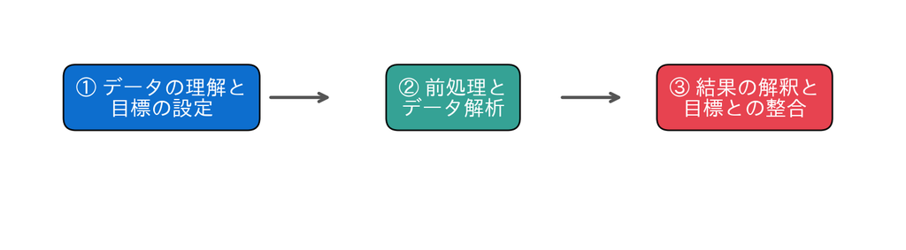

### 今日の道筋

次の7つの小さな問いに答えていきます。

1. 顔は数の表か？（1節）
2. 1本の向きで近似するには？（2節）
3. 顔の向きはどう見えるか？（3節）
4. 少ない数から顔を戻せるか？（4節）
5. 何本でどれだけ残るか？（5節）
6. 見分ける力は残るか？（6節）
7. 何個の数で持てばよいか？（7節）

## 1. 顔は数の表か？

表が読めました。1行の4,096個の数が、本当に顔なのかを確かめます。

### おさらい：並びの形を変える

`reshape`は、数の並びの形を変えます。6個の並びを2行×3列にすると、左から順に、1行目、2行目と詰めていきます。

```python
a = np.arange(6)                  # 0, 1, 2, 3, 4, 5
print(a.reshape(2, 3))
```

```
[[0 1 2]
 [3 4 5]]
```

画像の4,096個も、左上から右へ、1行ずつ並べたものです。`reshape(64, 64)`で、64行×64列の画像の形に戻せます。

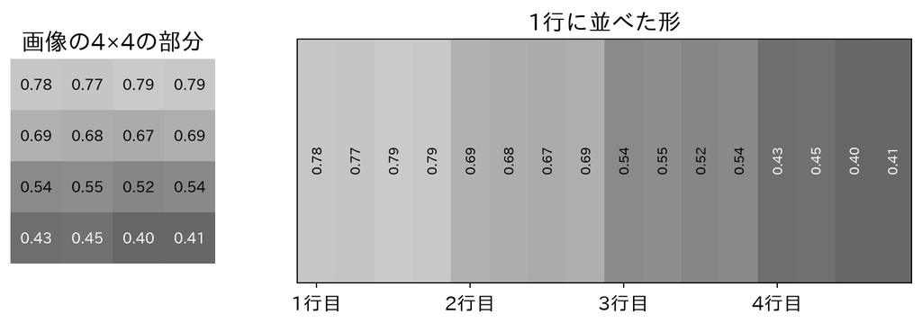

### お手本：1行を顔に戻す

- 役割：訓練の1枚目の4,096個を64行×64列に戻し、画像として描く
- 入力：訓練の画素`X_tr`と人の番号`p_tr`
- 出力：顔の画像

`plt.imshow`は、数の表を画像として描きます。`cmap='gray'`で、小さい数を黒、大きい数を白にします。

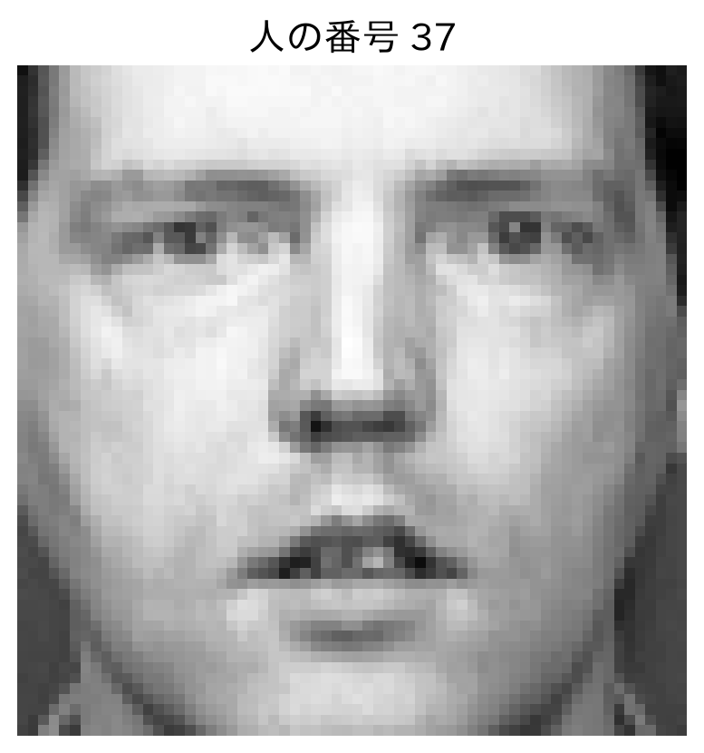

```python
img = X_tr[0].reshape(64, 64)       # 4,096個を64行×64列に
plt.imshow(img, cmap='gray')
plt.title(f'人の番号 {p_tr[0]}')
plt.axis('off')
plt.show()
```

4,096個の数が、顔になりました。この人の番号は37です。

### 変えてみる：同じ人の写真を並べる

- 役割：訓練の1枚目と同じ人の写真を取り出し、枚数を数えて、4枚を並べる
- 入力：訓練の画素と人の番号
- 出力：枚数と、顔の並び

`X_tr[p_tr == 37]`は、人の番号が37の行だけを残します（第1回の条件で絞る形を、配列に使う形です）。並べて描くのは、0節で用意した`show_faces`です。

```
8 枚
```

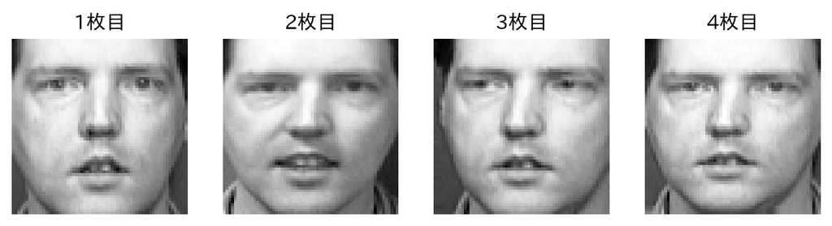

```python
same = X_tr[p_tr == 37]
print(len(same), '枚')
show_faces(same[:4], ['1枚目', '2枚目', '3枚目', '4枚目'])
```

番号37の人は、訓練に8枚あります。同じ人でも、表情や顔の向きが少しずつ違います。この違いがあっても、誰の顔かを見分けたいのです。

### お手本：平均の顔

- 役割：訓練の300枚で、画素ごとに明るさの平均を出し、顔として描く
- 入力：訓練の画素`X_tr`
- 出力：平均の顔

`X_tr.mean(axis=0)`は、縦の方向に（300枚をまたいで）平均し、画素ごとの平均を4,096個出します。pandasの`mean()`は列ごとが決まりでしたが、numpyでは`axis=0`で縦の方向を指定します。

```
(4096,)
```

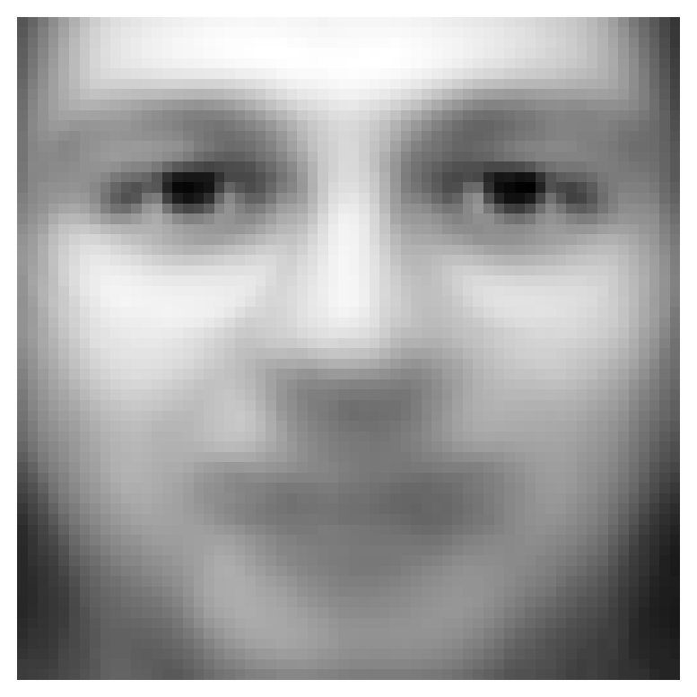

```python
mean_face = X_tr.mean(axis=0)       # 画素ごとの平均（4,096個）
print(mean_face.shape)
plt.imshow(mean_face.reshape(64, 64), cmap='gray')
plt.axis('off')
plt.show()
```

4,096個の平均が、ぼんやりした顔になりました。300枚の顔に共通する形です。

### 記号で書く：平均からのずれ

$i$枚目の画像の4,096個の数の並びを、$\mathbf{x}_i$と書きます。平均の顔を$\bar{\mathbf{x}}$と書くと、平均からのずれは$\mathbf{x}_i - \bar{\mathbf{x}}$です。

$$\bar{\mathbf{x}} = \frac{1}{n}\sum_{i=1}^{n} \mathbf{x}_i$$

$n$は枚数（訓練なら300）です。どの顔も「平均の顔＋その顔のずれ」です。顔ごとの違いは、ずれのほうにあります。

### TODO①：平均からのずれを描く

訓練の5枚目`X_tr[4]`と、平均の顔`mean_face`と、そのずれ`X_tr[4] - mean_face`の3つを、`show_faces`で並べてください。見出しは「写真」「平均」「ずれ」とします。

```python
# TODO: 5枚目・平均の顔・ずれ を並べて描く
# ヒント: show_faces([X_tr[4], mean_face, X_tr[4] - mean_face],
#                    ['写真', '平均', 'ずれ'])
...;
```

ずれの画像では、平均より明るい画素が白く、暗い画素が黒くなります。ずれの4,096個が、その顔らしさを表しています。今日は、このずれを少ない数で表す方法を考えます。

## 2. 1本の向きで近似するには？

顔は、平均の顔とずれでできていました。ずれは4,096個の数で、4,096次元の図は描けません。そこでまず、2画素だけで考えます。2画素なら、散布図に描けます。

### お手本：2画素を取り出す

- 役割：左右の目のあたりの2画素（20行目の20列目と44列目）を取り出し、2つの明るさの相関係数を出す
- 入力：訓練の画素`X_tr`
- 出力：取り出した表の大きさと、相関係数

20行目の20列目は、左上から数えて$20 \times 64 + 20 = 1300$番目の数です。44列目は1324番目です。`X_tr[:, [1300, 1324]]`は、すべての行の、その2列を取り出します。`np.corrcoef`は相関係数の表を返すので、`[0, 1]`で2つの間の相関係数を取ります。

```python
two = X_tr[:, [1300, 1324]]        # 20行目の20列目と44列目
print(two.shape)
print(np.corrcoef(two[:, 0], two[:, 1])[0, 1].round(3))
```

```
(300, 2)
0.817
```

300枚 × 2画素の表です。相関係数は0.817です。左の目のあたりが明るい写真は、右の目のあたりも明るい傾向があります。

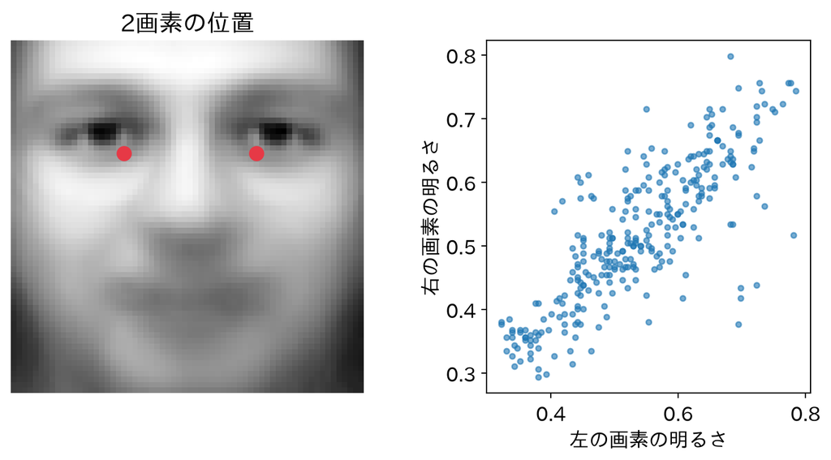

### 変えてみる：平均からのずれにする

- 役割：2画素それぞれの平均を引き、平均からのずれの表`xc`を作る
- 入力：2画素の表`two`
- 出力：ずれの平均（ほぼ0になる）

1節と同じく、`mean(axis=0)`で列ごとの平均を出し、各行から引きます。

```python
xc = two - two.mean(axis=0)        # 平均からのずれ
print(xc.mean(axis=0).round(3))
```

```
[0. 0.]
```

ずれの平均は、どちらも0です。点の集まりの中心が、原点に来ました。

### 1本の向きで近似する

ずれの点は、右上がりの細長い形に集まっています。そこで、原点を通る1本の直線を引き、各点を直線上の点で近似することを考えます。

直線の向きを、長さ1の矢印$\mathbf{w} = (\cos\theta, \sin\theta)$で表します。$\theta$は、横軸から測った角度です。点$\mathbf{x}_i$（ここでは、ずれ）から直線に垂直に下ろした足が、近似の点です。

- 得点：$t_i = \mathbf{x}_i \mathbf{w}^\top$（向きに沿って、どれだけ進んだ所か）
- 近似：$t_i \mathbf{w}$（直線上の点）
- 誤差：$\sum_{i} \| \mathbf{x}_i - t_i \mathbf{w} \|^2$（点と近似の点の距離の二乗を、全員で足す）

点を直線に垂直に下ろすことを、射影（projection）と呼びます。誤差がいちばん小さくなる向きを探します。

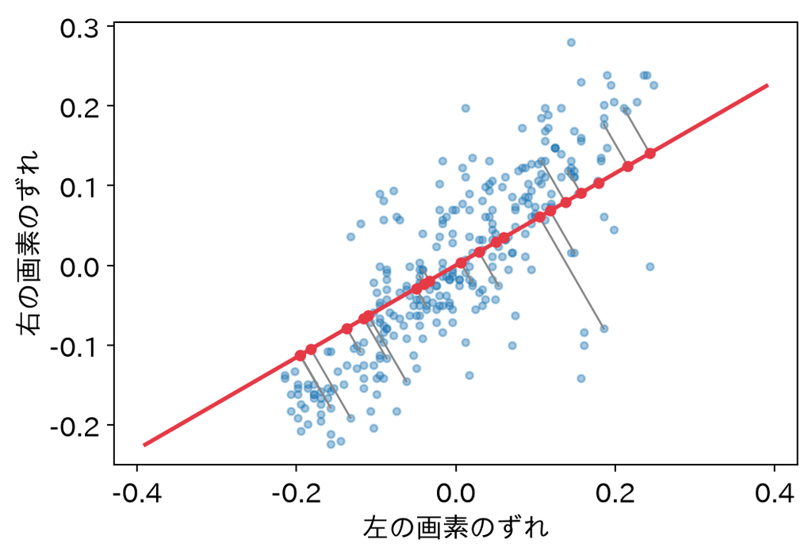

### おさらい：行列の積と転置

第2回で、正規方程式を`@`と`.T`で書きました。`@`は行列の積、`.T`は転置（行と列の入れ替え）です。1行2列の行列を転置すると、2行1列になります。

```python
A = np.array([[1, 2]])             # 1行2列
print(A.T)                           # 2行1列
print(np.array([[3, 4]]) @ A.T)      # (1行2列) @ (2行1列) → 1行1列
```

```
[[1]
 [2]]
[[11]]
```

$3 \times 1 + 4 \times 2 = 11$です。1行2列と2行1列の積は、2つの数を掛けて足した、1つの数になります。

### お手本：30度の向きで近似し、誤差を出す

- 役割：30度の向き$\mathbf{w}$を1行2列の行列`W`にし、得点・近似・誤差を計算する
- 入力：ずれの表`xc`
- 出力：得点と近似の大きさ、誤差

`np.deg2rad(30)`は、30度を、計算で使う角度の単位（ラジアン）に直します。`np.cos`・`np.sin`は、余弦と正弦です。得点は`xc @ W.T`で、300枚それぞれについて、2つの数を掛けて足します。近似は`t @ W`で、得点に向きを掛けます。

```python
theta = np.deg2rad(30)
W = np.array([[np.cos(theta), np.sin(theta)]])   # 向き：1行2列
t = xc @ W.T                       # 得点：300行1列
approx = t @ W                     # 近似：300行2列
print(t.shape, approx.shape)
print(round(((xc - approx) ** 2).sum(), 3))      # 誤差
```

```
(300, 1) (300, 2)
1.075
```

30度の向きの誤差は、1.075です。

### 変えてみる：向きを0〜179度で回す

- 役割：角度を1度ずつ変えて、それぞれの誤差を出し、誤差がいちばん小さい角度を探す
- 入力：ずれの表`xc`
- 出力：いちばん小さい誤差の角度と、その誤差

お手本と同じ計算を`for`で180回くり返します。`np.argmin`は、いちばん小さい値の位置を返します（第7回）。角度は0度から1度ずつなので、位置がそのまま角度です。

```python
errs = []
for deg in range(180):
    theta = np.deg2rad(deg)
    W = np.array([[np.cos(theta), np.sin(theta)]])
    t = xc @ W.T
    errs.append(((xc - t @ W) ** 2).sum())
best = np.argmin(errs)
print(best, '度', round(errs[best], 3))
```

```
45 度 0.666
```

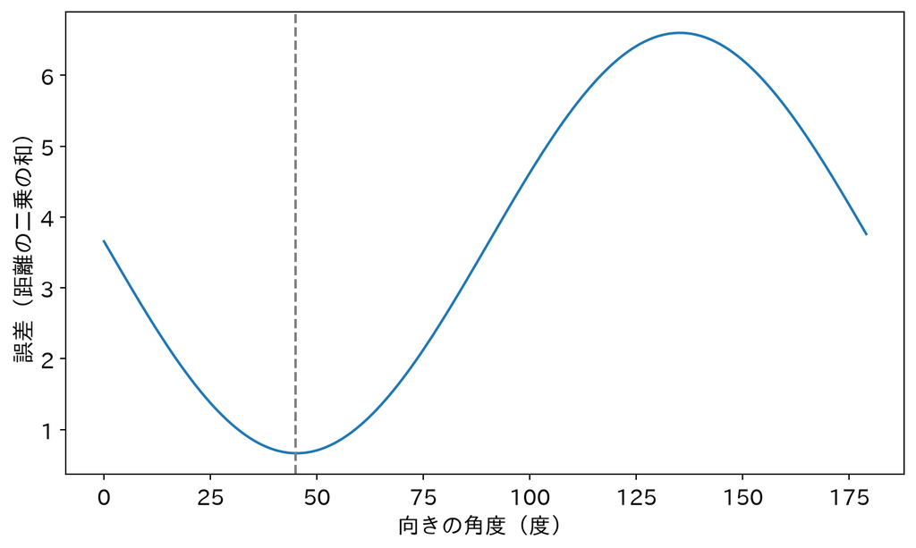

```python
plt.plot(range(180), errs)
plt.axvline(best, color='gray', ls='--')
plt.xlabel('向きの角度（度）')
plt.ylabel('誤差（距離の二乗の和）')
plt.show()
```

誤差は、45度でいちばん小さく、0.666です。点の集まりの細長い方向に、直線を合わせた形です。

### 名前：第1主成分

誤差がいちばん小さくなる向きを、第1主成分（principal component）と呼びます。点を第1主成分に射影した位置$t_i$を、主成分得点と呼びます。このように、平均からのずれを少ない本数の向きで近似する方法を、主成分分析（principal component analysis, PCA）と呼びます。

scikit-learnの`PCA`で、同じ向きが求まるかを確かめます。

### お手本：PCAで向きを求める

- 役割：2画素の表に主成分分析をかけ、第1主成分の向きを出す。45度の向きと比べる
- 入力：2画素の表`two`
- 出力：`PCA`の向きと、45度の向き

`PCA(n_components=1)`は、向きを1本だけ求める指定です。平均を引く計算は、`PCA`が中でします。求めた向きは`components_`に入ります。

```python
pca2 = PCA(n_components=1).fit(two)
print(pca2.components_.round(3))
theta = np.deg2rad(best)
print(np.round([np.cos(theta), np.sin(theta)], 3))
```

```
[[0.704 0.71 ]]
[0.707 0.707]
```

`PCA`の向きと、45度の向きは、ほぼ同じです（小さな違いは、1度ずつしか回していないためです）。符号が両方とも逆になることもありますが、矢印が逆向きなだけで、同じ直線です。

### 誤差が最小なら、得点の散らばりが最大

点$\mathbf{x}_i$と、近似の点$t_i \mathbf{w}$と、原点は、直角三角形を作ります。三平方の定理から、

$$\|\mathbf{x}_i\|^2 = t_i^2 + \|\mathbf{x}_i - t_i \mathbf{w}\|^2$$

全員で足すと、左辺の「ずれの大きさの合計」は、向きによらず一定です。だから、誤差（右辺の2つ目）が最小になる向きは、得点の二乗和（右辺の1つ目）が最大になる向きです。得点の平均は0なので、得点の二乗和が最大とは、得点の散らばり（分散）が最大ということです。

- 役割：45度の向きで、ずれの大きさの合計、得点の二乗和、誤差を出し、足し算が合うかを確かめる
- 入力：ずれの表`xc`、角度`best`
- 出力：3つの数

```python
theta = np.deg2rad(best)
W = np.array([[np.cos(theta), np.sin(theta)]])
t = xc @ W.T
print(round((xc ** 2).sum(), 3))             # ずれの大きさの合計
print(round((t ** 2).sum(), 3))              # 得点の二乗和
print(round(((xc - t @ W) ** 2).sum(), 3))   # 誤差
```

```
7.265
6.599
0.666
```

ずれの大きさの合計7.265は、得点の二乗和6.599と、誤差0.666の和です。第1主成分は、誤差がいちばん小さい向きであり、得点がいちばん散らばる向きでもあります。

### TODO②：直交する向きの誤差

第1主成分（45度）に直交（orthogonal）する向き、つまり45＋90＝135度の向きで、誤差を出してください。お手本の`np.deg2rad(30)`を`np.deg2rad(135)`に変えます。

```python
# TODO: 135度の向きで、得点・近似・誤差を計算し、誤差を表示する
# ヒント: お手本の theta = np.deg2rad(30) を 135 にする
...;
```

135度の向きの誤差は6.599で、180通りの中でいちばん大きくなります。直交する向きでは、得点の二乗和は0.666しかありません。第1主成分で残しきれなかった散らばりが、この向きに残っています。この向きを、第2主成分と呼びます。2画素なら、2本の向きで、ずれを誤差0で表せます。

## 3. 顔の向きはどう見えるか？

2画素では、誤差がいちばん小さい向きを、角度を回して探せました。4,096画素では、向きは4,096個の数の並びになり、角度を回して探すことはできません。同じ考え方の計算を、`PCA`に任せます。

### お手本：4,096画素で主成分分析

- 役割：訓練の300枚に主成分分析をかけ、向きの数と大きさ、平均を確かめる
- 入力：訓練の画素`X_tr`
- 出力：向きの表の大きさと、`PCA`の平均と1節の平均の顔の差

`n_components`を指定しないと、求められるだけの向きを求めます。`random_state=0`は、中の計算で乱数（random number）を使う場合に、毎回同じ結果にする指定です。`mean_`は、`PCA`が引いた平均です。

```python
pca = PCA(random_state=0).fit(X_tr)
print(pca.components_.shape)
print(np.abs(pca.mean_ - mean_face).max())
```

```
(300, 4096)
0.0
```

向きは300本で、1本が4,096個の数です。300枚から求めるので、向きは枚数までしか作れません。`PCA`の平均は、1節の平均の顔と同じです（差の最大は0）。

### 人の番号は使っていない

`PCA(...).fit(X_tr)`には、人の番号`p_tr`を渡していません。主成分分析は、答えの列を使わずに、画素の表だけから向きを求めます。

答えの列を使う解析を、教師あり学習と呼びました。答えの列を使わず、データそのものの形を調べる解析を、教師なし学習（unsupervised learning）と呼びます。主成分分析は、教師なし学習の1つです。

### お手本：向きを顔として描く

- 役割：最初の5本の向き（4,096個ずつ）を、顔の画像として描く
- 入力：`pca.components_`
- 出力：5枚の画像

向きも4,096個の数なので、`reshape(64, 64)`で画像にできます。顔のデータの向きを顔として描いたものを、固有顔（eigenface）と呼びます。白い画素は向きの値が大きく、黒い画素は小さい（マイナス）ことを表します。

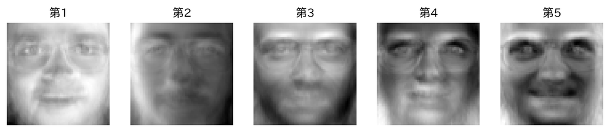

```python
show_faces(pca.components_[:5],
           ['第1', '第2', '第3', '第4', '第5'])
```

第1主成分は、顔全体がほぼ同じ色です。顔全体の明るさの違いを表す向きです。第2主成分は、左右で色が分かれています。光が左右どちらから当たっているかの違いです。第3主成分には眼鏡のあたり、第5主成分には口元の違いが出てきます。顔の形の違いは、3本目より先の向きに入っています。

写真どうしの違いが大きい順に、向きが並んでいます。いちばん大きい違いは、顔の形ではなく、撮ったときの光の当たり方でした。

### 寄与率：それぞれの向きが残す散らばり

2節で、得点の二乗和と誤差の和は、ずれの大きさの合計になりました。ずれの大きさの合計のうち、ある向きの得点が受け持つ割合を、その主成分の寄与率（proportion of variance explained）と呼びます。

$$\text{第}k\text{主成分の寄与率} = \frac{\text{第}k\text{主成分の得点の二乗和}}{\text{ずれの大きさの合計}}$$

- 役割：最初の5本の寄与率を出す
- 入力：`pca`
- 出力：5本の寄与率

```python
print(pca.explained_variance_ratio_[:5].round(3))
```

```
[0.23  0.141 0.081 0.049 0.037]
```

第1主成分の寄与率は0.23です。顔の画像のずれのうち、23%を、1本の向きで受け持っています。第2主成分は0.141、第3主成分は0.081と、だんだん小さくなります。

### 確かめる：行列の分解で、同じ向き

`PCA`の中では、特異値分解（singular value decomposition, SVD）という計算で向きを求めています。特異値分解は、ずれの表（行列）を、3つの行列の積に分ける計算です。numpyの`np.linalg.svd`で、同じ向きが出るかを確かめます。

- 役割：ずれの表`X_tr - mean_face`を特異値分解し、3つ目の行列`Vt`の1行目と、`PCA`の第1主成分を比べる
- 入力：訓練の画素と平均の顔
- 出力：`Vt`の大きさ、2つの向きの積の絶対値、`S`から出した寄与率

長さ1の向きどうしの積（`@`）は、同じ向きなら1（逆向きなら−1）になります。`full_matrices=False`は、必要な大きさだけを返す指定です。

```python
U, S, Vt = np.linalg.svd(X_tr - mean_face, full_matrices=False)
print(Vt.shape)
print(abs(Vt[0] @ pca.components_[0]).round(3))
print((S ** 2 / (S ** 2).sum())[:3].round(3))
```

```
(300, 4096)
1.0
[0.23  0.141 0.081]
```

`Vt`の行が、`PCA`の向きと同じです（積の絶対値が1）。`S`の二乗の割合が、寄与率と一致します。`PCA`の1行は、この行列の計算をまとめたものです。

## 4. 少ない数から顔を戻せるか？

向きが求まりました。顔1枚を、最初の何本かの向きの得点だけで持てば、数が少なくなります。その少ない数から、顔を戻せるでしょうか。

### 記号で書く：縮める・戻す

2節の1本の向きを、$k$本に広げます。$k$本の向き（1本が4,096個）を縦に並べた$k$行4,096列の行列を$\mathbf{W}$、ずれの表（1行が1枚）を$\mathbf{X} - \bar{\mathbf{x}}$と書きます。

- 縮める（得点）：$\mathbf{T} = (\mathbf{X} - \bar{\mathbf{x}})\,\mathbf{W}^\top$ 1枚が$k$個の数になる
- 戻す（再構成）：$\hat{\mathbf{X}} = \mathbf{T}\,\mathbf{W} + \bar{\mathbf{x}}$ $k$個の数から4,096画素に戻す

2節の`t = xc @ W.T`と`t @ W`と、同じ形です。少ない数から元の形に戻すことを、再構成（reconstruction）と呼びます。

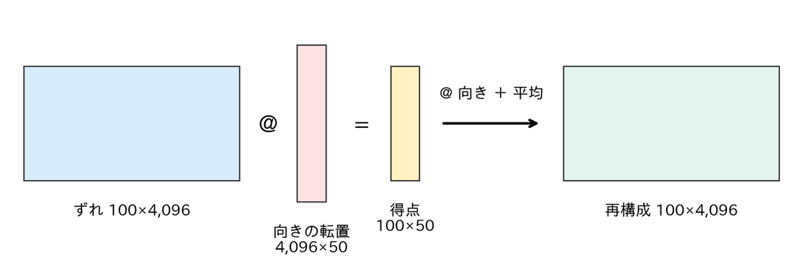

### お手本：テストの顔を50本で縮めて戻す

- 役割：最初の50本の向きで、テストの100枚を得点にし、得点から再構成する。テストの1枚目の写真と再構成を並べる
- 入力：テストの画素`X_te`、向き`pca.components_`、平均の顔
- 出力：得点と再構成の大きさ、2枚の顔

`pca.components_[:50]`は、最初の50行（50本の向き）です。向きと平均は訓練の300枚で決めたものを、そのままテストに使います（第3回の「訓練だけで決める」）。

```
(100, 50) (100, 4096)
```

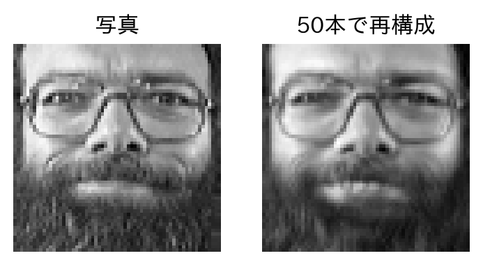

```python
W = pca.components_[:50]           # 50本の向き：50行4,096列
T = (X_te - mean_face) @ W.T       # 得点：100行50列
X_hat = T @ W + mean_face          # 再構成：100行4,096列
print(T.shape, X_hat.shape)
show_faces([X_te[0], X_hat[0]], ['写真', '50本で再構成'])
```

テストの100枚が、1枚50個の数になりました。その50個から戻した顔は、元の写真とよく似ています。

この顔は、主成分を求めた訓練の300枚には入っていません。まだ見ていない顔でも、50本の向きで、おおよそ表せています。

### 確かめる：PCAのtransformも同じ計算

`PCA`の`transform`は、得点を出す部品です。お手本の`T`の先頭と、`transform`の先頭を比べます。

```python
print(T[0, :3].round(3))
print(pca.transform(X_te)[0, :3].round(3))
```

```
[-6.944  0.952  3.819]
[-6.944  0.952  3.819]
```

同じ数です。`transform`の中身は、ずれ`@`向きの転置でした。第7回で読んだ`StandardScaler`の`transform`と同じく、`fit`で覚えたもの（平均と向き）を使って、新しい行を変換します。

### TODO③：本数を変えて戻す

テストの1枚目`X_te[0]`を、向きの本数`k`を5・20・50・100に変えて再構成し、元の写真と並べて描いてください。`for`の中で、お手本の`50`を`k`に変えます。テストの1枚目だけなので、`X_te[[0]]`（1行の表）で計算します。

```python
# TODO: k = 5, 20, 50, 100 で X_te[0] を再構成し、写真と並べる
# ヒント: faces = [X_te[0]]
#         for k in [5, 20, 50, 100]:
#             W_k = pca.components_[:k]
#             T_k = (X_te[[0]] - mean_face) @ W_k.T
#             faces.append((T_k @ W_k + mean_face)[0])
#         show_faces(faces, ['写真', '5本', '20本', '50本', '100本'])
...;
```

5本では、眼鏡のあたりが分かるだけの、ぼんやりした顔です。20本で、ひげや口元が出てきて、50本・100本と増やすほど、細かいところまで戻ります。数を増やすほど、元の写真に近づきます。

どこまで増やせば十分かを、次の節で数で確かめます。

## 5. 何本でどれだけ残るか？

本数を増やすほど、元の写真に近づきました。何本でどれだけ残るかを、2つの数で確かめます。訓練の300枚の散らばりがどれだけ残るか（累積寄与率）と、テストの顔をどれだけ正確に戻せるか（再構成誤差）です。

### お手本：累積寄与率

最初の$k$本の寄与率を足したものを、累積寄与率（cumulative proportion of variance explained）と呼びます。$k$本の向きで、ずれの大きさの合計のうち何割を受け持つかを表します。

- 役割：寄与率を前から順に足していき、1・10・50・100本での累積寄与率を出し、線で描く
- 入力：`pca.explained_variance_ratio_`
- 出力：4つの累積寄与率と、線の図

`cumsum`は、前から順に足していった並びを返します。`cum[9]`は10本目までの和です（位置は0から数えるので、1本ずれます）。

```
[0.23  0.655 0.88  0.945]
```

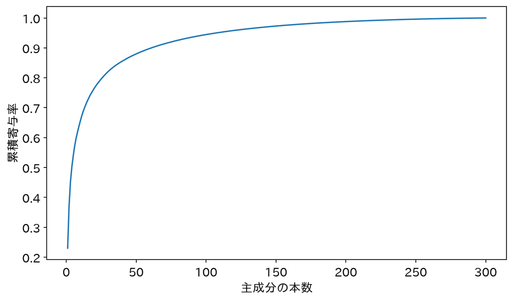

```python
cum = pca.explained_variance_ratio_.cumsum()
print(cum[[0, 9, 49, 99]].round(3))
plt.plot(range(1, 301), cum)
plt.xlabel('主成分の本数')
plt.ylabel('累積寄与率')
plt.show()
```

1本で0.23、10本で0.655、50本で0.88、100本で0.945です。はじめの数十本で急に増え、そのあとはゆっくり1に近づきます。300本すべてを使えば、1（訓練の300枚を誤差0で表せる）です。

### TODO④：初めて0.9を超える本数

累積寄与率が初めて0.9以上になる本数を出してください。`cum >= 0.9`はTrue/Falseの並びで、`np.argmax`は、いちばん大きい値（Trueは1、Falseは0）が最初に出る位置を返します。位置は0から数えるので、本数は`+ 1`します。

```python
# TODO: 累積寄与率が初めて 0.9 以上になる本数を出す
# ヒント: np.argmax(cum >= 0.9) + 1
...;
```

61本で、累積寄与率が初めて0.9を超えます。4,096個の数のうち、61個で、訓練の顔の散らばりの9割を表せます。

### お手本：テストの顔の再構成誤差

累積寄与率は、向きを求めた訓練の300枚の数です。まだ見ていないテストの顔も、同じように戻せるかを確かめます。

- 役割：本数`k`を変えて、テストの100枚を再構成し、画素1つあたりの誤差の二乗の平均（再構成誤差）を出す。平均の顔だけで戻したとき（0本）の誤差も出す
- 入力：テストの画素、向き、平均の顔
- 出力：本数ごとの再構成誤差と、線の図

```
[0.0202 0.0091 0.0071 0.0053 0.0035 0.0026 0.002 ]
```

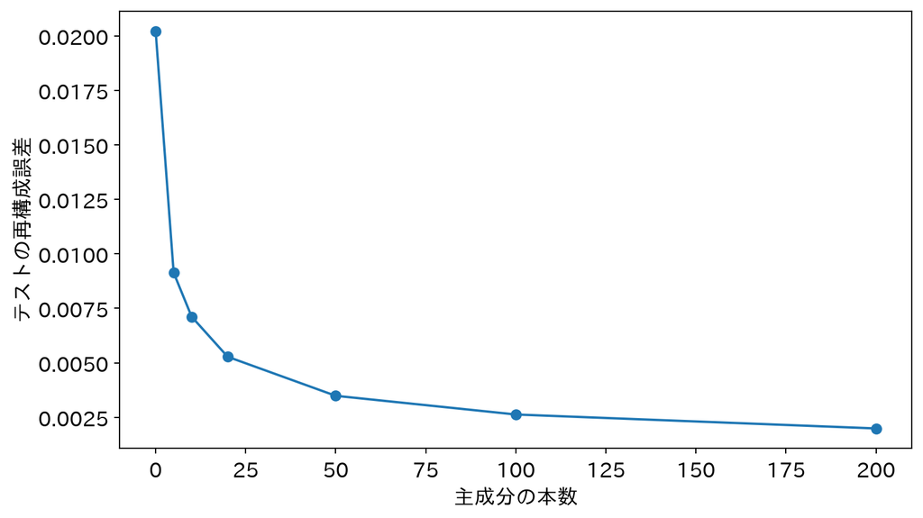

```python
ks = [0, 5, 10, 20, 50, 100, 200]
rec_err = []
for k in ks:
    W_k = pca.components_[:k]
    X_hat_k = (X_te - mean_face) @ W_k.T @ W_k + mean_face
    rec_err.append(((X_te - X_hat_k) ** 2).mean())
print(np.round(rec_err, 4))
plt.plot(ks, rec_err, marker='o')
plt.xlabel('主成分の本数')
plt.ylabel('テストの再構成誤差')
plt.show()
```

平均の顔だけ（0本）では0.0202、50本で0.0035、100本で0.0026です。テストの顔でも、本数を増やすほど誤差は小さくなります。ただし、50本を超えると、減り方はゆるやかになります。

ここまでで分かったのは、50本ほどで、顔の見た目がかなり残ることです。けれども、顔認証で大事なのは、見た目がどれだけ戻るかではなく、誰の顔かを見分けられるかです。

## 6. 見分ける力は残るか？

50本ほどで、顔の見た目はかなり戻りました。では、50個の数で持った顔で、誰の顔かを見分けられるでしょうか。まず、見分ける方法を決めます。

### 1-最近傍法

カメラに写った顔に、いちばん近い登録の顔を探し、その人だと答える方法を、1-最近傍法（1-nearest neighbor）と呼びます。近さは、2つの顔の、画素ごとの差の二乗の和で測ります。

$$d(\mathbf{x}, \mathbf{x}_j) = \sum_{\text{画素}} (\text{差})^2 = \|\mathbf{x} - \mathbf{x}_j\|^2$$

ここでは、訓練の300枚を登録の顔、テストの顔をカメラに写った顔とみなします。

### お手本：1枚で、いちばん近い顔を探す

- 役割：テストの1枚目と、訓練の300枚それぞれの距離を出し、いちばん近い1枚の人の番号を答える
- 入力：訓練の画素と人の番号、テストの1枚目
- 出力：いちばん近い距離、その人の番号、本当の番号

`X_tr - x`は、300行4,096列の表から、4,096個の並び`x`を引く計算です。numpyは、`x`を300行ぶん繰り返して、各行から引きます（ブロードキャストと呼びます）。1節で平均の顔を引いたのも、この形でした。`sum(axis=1)`は、横の方向（行ごと）に足します。

```
16.7 36 36
```

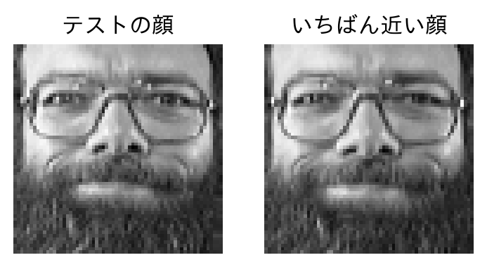

```python
x = X_te[0]
d = ((X_tr - x) ** 2).sum(axis=1)  # 300枚それぞれとの距離
near = np.argmin(d)
print(round(d[near], 2), p_tr[near], p_te[0])
show_faces([x, X_tr[near]], ['テストの顔', 'いちばん近い顔'])
```

いちばん近い顔は、番号が同じ人でした。当たりです。

### 部品：KNeighborsClassifier

いちばん近い顔を探して答える部品が、scikit-learnの`KNeighborsClassifier`です。`n_neighbors=1`で、いちばん近い1枚の答えを使います。

- `fit`：登録の顔と人の番号を、そのまま覚える
- `predict`：新しい顔ごとに、覚えた顔のうちいちばん近い1枚の番号を返す
- `score`：当てた割合（正解率）を返す（第6回）

### お手本：画素そのままで交差検証

テストは最後に1回だけ使いたいので、本数の比べ合いは、訓練の300枚の交差検証で行います（第4回）。人ごとの割合をそろえて5つの組に分けます（`StratifiedKFold`、第6回）。

- 役割：4,096画素そのままの1-最近傍法を、5つの組で交差検証し、正解率を出す
- 入力：訓練の画素と人の番号
- 出力：5回分の正解率と、その平均

分類（classification）の部品では、`cross_val_score`は正解率を返します。

```python
skf = StratifiedKFold(n_splits=5, shuffle=True, random_state=0)
knn = KNeighborsClassifier(n_neighbors=1)
sc_raw = cross_val_score(knn, X_tr, p_tr, cv=skf)
print(sc_raw.round(3))
print(round(sc_raw.mean(), 3))
```

```
[0.9   0.883 0.917 0.9   0.933]
0.907
```

4,096画素そのままでは、交差検証の正解率は0.907です。40人から、9割ほどを当てています。これを、縮めたときに比べる相手にします。

### お手本：50本に縮めてから見分ける

- 役割：主成分分析（50本）と1-最近傍法をつないだパイプラインを作り、交差検証で正解率を出す
- 入力：訓練の画素と人の番号
- 出力：5回分の正解率と、その平均

パイプラインに入れたので、交差検証の各回で、`PCA`はその回の訓練の顔だけで向きを求めます（第7回・第8回の「答えを使う手順は中へ」と同じ形です。`PCA`は答えを使いませんが、評価用の顔を見ずに向きを決めるためです）。

```python
pipe50 = make_pipeline(PCA(n_components=50, random_state=0),
                       KNeighborsClassifier(n_neighbors=1))
sc_50 = cross_val_score(pipe50, X_tr, p_tr, cv=skf)
print(sc_50.round(3))
print(round(sc_50.mean(), 3))
```

```
[0.9   0.883 0.9   0.917 0.9  ]
0.9
```

50本に縮めても、交差検証の正解率は0.9です。4,096画素そのままの0.907と、ほとんど変わりません。

累積寄与率は0.88で、散らばりの1割強は捨てています。それでも見分ける力が残るのは、捨てた向きの多くが、人の違いではなく、細かい雑音のような違いだからです。人を見分ける違いは、はじめの数十本の向きに入っています。

### TODO⑤：20本では？

お手本の`n_components=50`を20に変えて、交差検証の正解率の平均を出してください。

```python
# TODO: 20本に縮めてから見分けるパイプラインで、交差検証の正解率を出す
# ヒント: pipe20 = make_pipeline(PCA(n_components=20, random_state=0),
#                                KNeighborsClassifier(n_neighbors=1))
#         cross_val_score(pipe20, X_tr, p_tr, cv=skf).mean()
...;
```

20本では、正解率は0.877です。50本の0.9より下がります。少なくしすぎると、見分ける力も落ちていきます。

## 7. 何個の数で持てばよいか？

50本なら見分ける力が残り、20本では少し落ちました。最後に、何個の数で持つかを決め、まだ見ていないテストの100枚で1回だけ確かめます。

### 50個を選ぶ

交差検証の正解率は、4,096画素そのままで0.907、50本で0.9、20本で0.877でした。50本は、4,096画素とほぼ同じ力で、数は次のとおり少なくなります。

- 役割：50個が4,096個の何%かを出す
- 入力：なし
- 出力：割合

```python
print(round(50 / 4096 * 100, 1), '%')
```

```
1.2 %
```

1枚を、元の1.2%の数で持てます。ここでは、50個を選びます。選ぶのは、テストではなく交差検証の結果です（第8回）。

### お手本：テストで1回だけ確かめる

- 役割：4,096画素そのままの1-最近傍法と、50本のパイプラインを、訓練の300枚全員で作り、テストの100枚の正解率を出す
- 入力：訓練とテストの画素と人の番号
- 出力：2つの正解率

```python
knn.fit(X_tr, p_tr)
pipe50.fit(X_tr, p_tr)
print(knn.score(X_te, p_te))
print(pipe50.score(X_te, p_te))
```

```
0.93
0.93
```

テストの100枚では、4,096画素そのままも50本も、正解率は0.93です。50本にしても、当たった枚数は変わりません。

### お手本：外れた顔を見る

- 役割：50本のパイプラインで外れたテストの顔を数え、先頭の4枚を描く
- 入力：50本のパイプライン、テストの画素と人の番号
- 出力：外れた枚数と、外れた顔

```
7 枚
```

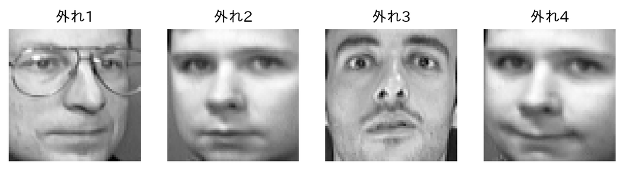

```python
pred = pipe50.predict(X_te)
miss = X_te[pred != p_te]
print(len(miss), '枚')
show_faces(miss[:4], ['外れ1', '外れ2', '外れ3', '外れ4'])
```

### 答え

顔の画像1枚（4,096画素）は、主成分分析で50個の数（元の1.2%）にしても、誰の顔かを見分ける力はほとんど落ちません。交差検証の正解率は4,096画素そのままで0.907、50本で0.9でした。テストの100枚では、どちらも0.93でした。50本の累積寄与率は0.88で、捨てた1割強は、見分けるのにあまり役立たない違いでした。

20本まで減らすと、正解率は0.877に下がります。開発チームには、50個を目安に持つことを提案できます。

まだ言えないこと

- ほかの撮り方でも同じか：このデータは、同じ部屋で、顔の位置をそろえて撮った写真。明るさや顔の位置が違うカメラの写真では、主成分の向きそのものが変わりうる
- 40人より多いときも同じか：登録する人が増えると、見分けるのに必要な本数も増えうる
- 登録していない人をどう扱うか：1-最近傍法は、必ず誰かを答える。知らない人を「登録なし」と答える仕組みは、別に要る

## 目標に答えられたか

- 今日の目標は「顔の画像1枚を、見分ける力を保ったまま、何個の数で持てばよいか」でした。答えを、本数と正解率で説明できますか？
- 1節で、4,096個の数の並びを顔に戻すには、どうしましたか？ 平均の顔とずれは、何を表しますか？
- 2節で、誤差がいちばん小さい向きが、得点がいちばん散らばる向きでもあるのはなぜですか？
- 3節で、主成分分析が教師なし学習なのはなぜですか？ 第1・第2主成分の固有顔は、何の違いを表していましたか？
- 4節で、縮める・戻すを、行列の積でどう書きましたか？
- 5節の累積寄与率と再構成誤差は、それぞれ何を測っていましたか？
- 6節で、累積寄与率が0.88でも見分ける力が残ったのはなぜですか？

## 今日の要点

- 今日、持ち帰る1文：主成分分析は、データを平均からのずれの「誤差が最小になる向き」で近似する。縮めるのも戻すのも行列の積で書け、顔なら4,096個の数を50個にしても、誰の顔かを見分ける力はほとんど落ちない
- 画像は、画素の明るさの並び。`reshape(64, 64)`で画像に戻せる。どの顔も、平均の顔＋ずれ
- 第1主成分は、ずれを1本の向きで近似したときの誤差が最小の向き。三平方の定理から、得点の散らばりが最大の向きでもある
- 主成分分析は答えの列を使わない（教師なし学習）。向きを顔として描いたものが固有顔
- 得点＝ずれ`@`向きの転置、再構成＝得点`@`向き＋平均
- 累積寄与率は訓練の散らばりが何割残るか、再構成誤差はまだ見ていない顔をどれだけ戻せるか。見分ける力は、交差検証の正解率で別に確かめる
- Python：`mean(axis=0)`は縦の方向、`sum(axis=1)`は横の方向。表から1行を引くと、各行から引かれる（ブロードキャスト）

## 次回へ

今日は、主成分の向きを顔として描き、第1主成分は顔全体の明るさ、第2主成分は光の当たり方だと読みました。画像なら、向きを絵にして読めます。

次回の問いは、身長や価格のように、単位も意味も違う列が並んだデータでは、主成分の向きや得点を、どう読めばよいか、です。

## 課題（提出）

提出するもの：応用②の答えと、応用③の文章。提出フォームに入力してください。期限はありません。応用①のコードは提出しませんが、②の答えを出すために必要です。

### 応用①（変形）

6節のパイプラインの主成分の本数を10・30・100に変えて、交差検証の正解率の平均を並べてください。`for`で本数`k`を回し、`PCA(n_components=k, random_state=0)`とします。

```python
# ここにコードを書く
...;
```

**詰まったら**

`for k in [10, 30, 100]:`の中で、パイプラインを作り、`cross_val_score(pipe, X_tr, p_tr, cv=skf).mean()`を表示します。 本編の50本は0.9、20本は0.877、4,096画素そのままは0.907でした。

### 応用②（判断）

応用①の3つ（10・30・100本）と本編の20本・50本のうち、交差検証の正解率が、4,096画素そのまま（0.907）より0.01以上は下がらない、いちばん少ない本数はどれですか。本数を整数で答えてください（例: 25）。

```python
# ここにコードを書く
...;
```

**詰まったら**

4,096画素そのままの正解率から、それぞれの正解率を引き、差が0.01より小さいものの中で、いちばん少ない本数を選びます。テストの正解率では選ばないようにしましょう。

### 応用③（解釈）

開発チームに向けて、今日の解析で分かったことを3行程度で報告してください。1枚を何個の数で持つとよいか、そのときの見分ける力（正解率）、まだ確かめていないこと、を入れましょう。

（ここに3行程度で書く）

## 発展（任意）

### 固有顔の向きに、平均の顔を動かす

3節で、第1主成分は顔全体の明るさ、第2主成分は光の当たり方と読みました。平均の顔を、それぞれの向きに沿って動かすと、本当にそう変わるかを確かめます。

- 役割：平均の顔に、第1主成分の向きを、得点の標準偏差の−2倍から＋2倍まで足した5枚を描く
- 入力：平均の顔、`pca`
- 出力：5枚の顔

`pca.explained_variance_`は、各主成分の得点の分散です。`np.sqrt`で標準偏差にします。

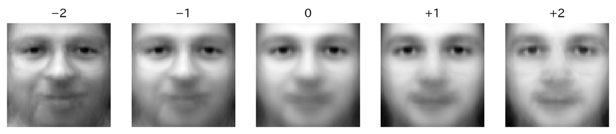

```python
sd = np.sqrt(pca.explained_variance_[0])   # 第1主成分の得点の標準偏差
faces = []
for c in [-2, -1, 0, 1, 2]:
    faces.append(mean_face + c * sd * pca.components_[0])
show_faces(faces, ['−2', '−1', '0', '+1', '+2'])
```

第1主成分の向きに動かすと、顔全体の明るさが変わります（＋の側では顔が明るく、まわりが暗くなります）。真ん中（0）が平均の顔です。

試すなら、`[0]`を`[1]`に変えて、第2主成分の向きに動かしてみましょう。＋の側では、顔の左半分が明るく、右半分が暗くなります。光が当たる向きの違いです。`[2]`や`[3]`では、どんな違いが見えるでしょうか。

### 第8回の「まとまりの平均」は、主成分とどう違うか

第8回では、TRIM32と一緒に動く527本の遺伝子のまとまりを、標準化した発現量の平均で1本の点数にしました。同じ527本に主成分分析をかけ、第1主成分の得点と、平均の点数を比べます。

- 役割：第8回と同じ手順で、遺伝子を10のまとまりに分け、7番のまとまり（527本）の、平均の点数と第1主成分の得点の相関係数を出す
- 入力：第8回の遺伝子発現のデータ
- 出力：まとまりの大きさ、第1主成分の寄与率、相関係数

第8回のセルを1つにまとめたものです。読み込みと階層的クラスタリングで、少し時間がかかります。

```python
from scipy.cluster.hierarchy import linkage, fcluster
rat = pd.read_csv(f'{DATA_DIR}/rat_eye_full.csv.gz', index_col=0)
g_tr, g_te = train_test_split(rat.drop(columns='TRIM32'),
                              test_size=0.25, random_state=0)
g_tr = g_tr.loc[:, ~g_tr.columns.str.startswith('AFFX')]
g_tr = g_tr.loc[:, g_tr.mean() > g_tr.mean().median()]
var_top = g_tr.var().sort_values(ascending=False).index[:2000]
Z = linkage(g_tr[var_top].T, 'average', metric='correlation')
groups = pd.Series(fcluster(Z, 10, 'maxclust'), index=var_top)
Zs = (g_tr[var_top] - g_tr[var_top].mean()) / g_tr[var_top].std()
g7 = Zs.loc[:, groups == 7]
avg7 = g7.mean(axis=1)                       # 第8回の点数
pca7 = PCA(n_components=1).fit(g7)
s7 = pca7.transform(g7)[:, 0]                # 第1主成分の得点
print(g7.shape)
print(pca7.explained_variance_ratio_.round(3))
print(np.corrcoef(avg7, s7)[0, 1].round(3))
```

```
(90, 527)
[0.394]
0.994
```

527本のまとまりでは、第1主成分の寄与率は0.394で、平均の点数と第1主成分の得点の相関係数は0.994です。ほとんど同じ点数です。

平均は、527本すべてに同じ重みを付けて足す縮め方です。主成分分析は、誤差がいちばん小さくなるように、遺伝子ごとに重み（向きの値）を決めます。一緒に動く遺伝子のまとまりでは、どの遺伝子もほぼ同じ重みになるので、2つはほぼ一致します。第8回の平均は、第1主成分のいちばん単純な近似だったのです。

試すなら、`pca7.components_[0]`の値を`plt.hist`で描き、527本の重みが、すべて同じ重み（$1/\sqrt{527}$）のまわりに集まるかを見てみましょう。